# Part II - Prosper Data Analysis

## by Ntombi Mashila

## Investigation Overview

> This presentation seeks to convey the results of the explanatory anlyssis performed on Prosper Loan data in order to help the company improve on it's Lending strategy.

## Dataset Overview

> The Prosper data set contains 113,937 loans with 81 variables on each loan, including loan amount, borrower rate (or interest rate), current loan status, borrower income, and many others. I decided to focus on loans that have resulted in a net loss for the bank. I used the feature LP_NetPrincipalLoss to create a subset of the Prosper data set.

## Visualization 1

> The score dsitribution is bell shaped, with most customers scoring at the middle of the distribution and very few customers at the lower and upper tails. This is typical of any scoring distribution.

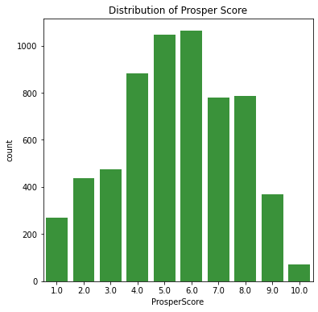

## Visualization 2

> There is a positive correlation between LoanOriginalAmount and NetPrincipaLoss.

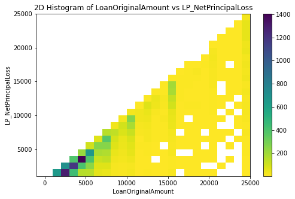

## Visualization 3

> Wedding Loans and business loans have very long tails. This tells us that the the Lender incurs large losses for these type of loans when they default.

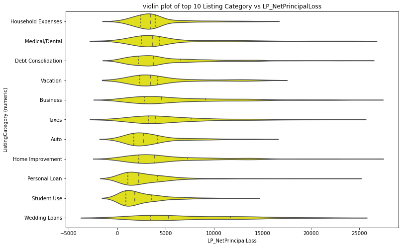

## Visualization 4

> The longer the term of the loan the higher the loss amount

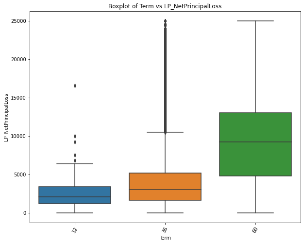

## Visualization 5

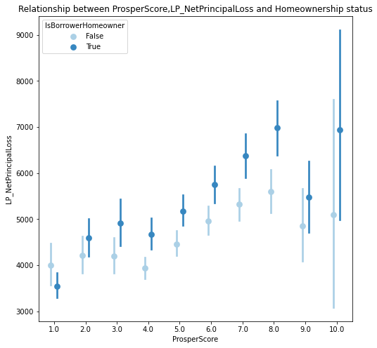